# Sentiment Analysis: Shopee App Reviews (SG)

```python
%%capture
!pip install emoji
!pip install wordcloud
!pip install imblearn
!pip install tensorflow
```

## Setup Base Directory

```python
from google.colab import drive
drive.mount('/content/drive')
```

```python
BaseDir = '/content/drive/MyDrive/Colab Notebooks/Sentiment-Analysis/'
```

## Library

```python
import pandas as pd
import numpy as np
import matplotlib.pyplot as plt
import seaborn as sns

import re
import string
import emoji
import nltk
from nltk.tokenize import word_tokenize
from nltk.corpus import stopwords
from wordcloud import WordCloud
from nltk.stem import PorterStemmer
from nltk.stem import WordNetLemmatizer
from sklearn.feature_extraction.text import CountVectorizer

nltk.download('punkt')
nltk.download('stopwords')

pd.set_option('display.max_colwidth', None)

sns.set(style='whitegrid', palette='muted', font_scale=1.2)
HAPPY_COLORS_PALETTE = ["#01BEFE", "#FFDD00", "#FF7D00", "#FF006D", "#ADFF02"]
sns.set_palette(sns.color_palette(HAPPY_COLORS_PALETTE))
plt.figure(figsize=(8, 4))
```

## Function

### Text Preprocessing

```python
def cleaningText(text):
    text = text.lower()               # Mengubah teks menjadi huruf kecil
    text = re.sub(r'@\w+', '', text)  # Hapus mention
    text = re.sub(r'#\w+', '', text)  # Hapus hashtag
    text = re.sub(r'https?://\S+|www.\S+', '', text)  # Hapus URL
    text = re.sub(r'<.*?>', '', text) # Hapus tag HTML
    text = re.sub(r'\d+', '', text)   # Hapus angka
    text = re.sub(r'[^\x00-\x7F]+', '', text)  # Hapus karakter non-ASCII
    text = emoji.replace_emoji(text, '')  # Hapus emotikon
    text = re.sub(r'[\u00B2\u00B3\u00B9\u2070-\u2079]', '', text)  # Hapus superscript
    text = text.replace('\n', ' ')    # Ganti baris baru dengan spasi
    text = re.sub(r'[{}]'.format(re.escape(string.punctuation)), ' ', text) # Mengganti tanda baca dengan spasi
    text = text.strip()               # Hapus spasi tambahan di awal dan akhir
    text = re.sub(r'\s+', ' ', text)  # Hapus spasi ganda
    return text

# Memecah atau membagi string, teks menjadi daftar token
def tokenizingText(text):
    text = word_tokenize(text)
    return text

# Menghapus stopwords
def filteringText(text):
    listStopwords = set(stopwords.words('english'))
    # listStopwords = set(stopwords.words('indonesian'))
    # listStopwords.update(listStopwords1)
    # listStopwords.update(['iya','yaa','gak','nya','nah','sih','ku',"di","ga","ya","gaa","loh","kah","woi","woii","woy"])
    filtered = []
    for txt in text:
        if txt not in listStopwords:
            filtered.append(txt)
    text = filtered
    return text

# Mengurangi kata ke bentuk dasarnya
def stemmingText(text):
    stemmer = PorterStemmer()
    words = text.split()
    stemmed_words = [stemmer.stem(word) for word in words]
    stemmed_text = ' '.join(stemmed_words)
    return stemmed_text

# Mengubah menjadi kalimat
def toSentence(list_words):
    sentence = ' '.join(word for word in list_words)
    return sentence
```

### Exploratory Data Analysis (EDA)

```python
def graph_freq(df, text_column, label_column=None, label_value=None):

    if label_column is not None and label_value is not None:
        filtered_df = df[df[label_column] == label_value]
    else:
        filtered_df = df

    cv = CountVectorizer()
    data = filtered_df[text_column]
    words = cv.fit_transform(data)
    sum_words = words.sum(axis=0)

    words_freq = [(word, sum_words[0, i]) for word, i in cv.vocabulary_.items()]
    words_freq = sorted(words_freq, key=lambda x: x[1], reverse=True)
    frequency = pd.DataFrame(words_freq, columns=['word', 'freq'])

    # Plotting
    frequency.head(50).plot(x='word', y='freq', kind='bar', figsize=(15, 5), cmap='magma')
    plt.title("Most Frequently Occurring Words - Top 50")
    plt.show()

def wordcloud(df, text_column):
  result_wordcloud = WordCloud(background_color="white", width=8000, height=4000, max_words=1000).generate(' '.join(df[text_column]))
  plt.imshow(result_wordcloud)
  plt.axis("off")
  plt.show()
```

### Labelling

```python
# Menggunakan score (rating) untuk memberikan label
def score_label(rating):
  rating = int(rating)
  if rating < 2:
    return 'positive'
  elif rating > 3:
    return 'negative'
  else:
    return 'neutral'

# Menggunakan keyword tertentu untuk memberikan label
# Keyword ini didapatkan dari Frequency word based Score
positive_keywords = ['great', 'excellent', 'good', 'easy', 'friendly', 'love', 'fast', 'best', 'nice']
negative_keywords = ['bad', 'unable','terrible', 'poor', 'slow', 'lagging', 'lag', 'issue']

def Label(content):
    # content = content.lower()
    for word in positive_keywords:
        if word in content:
            return 'positive'
    for word in negative_keywords:
        if word in content:
            return 'negative'
    return 'neutral'

# Encoding Label
label_mapping = {'negative': 0, 'positive': 1,  'neutral': 2}

def map_labels(label):
    return label_mapping[label]
```

## Load Dataset

```python
df = pd.read_csv(BaseDir + 'dataset/shopee-en-sg-all.csv')
df.head(1)
```

|  | reviewId | userName | userImage | content | score | thumbsUpCount | reviewCreatedVersion | at | replyContent | repliedAt | appVersion |
| --- | --- | --- | --- | --- | --- | --- | --- | --- | --- | --- | --- |
| 0 | c5689c61-60cc-4e9b-b426-5c1982580aea | A Google user | https://play-lh.googleusercontent.com/EGemoI2NTXmTsBVtJqk8jxF9rh8ApRWfsIMQSt2uE4OcpQqbFu7f7NbTK05lx80nuSijCz7sc3a277R67g | I wouldn't use this app again, at least for a long time until they catch up on both the technological and human performances. The pages load extremely slowly or cannot load, they don't integrate with … | 1 | 108 | 2.54.16 | 2020-04-30 10:39:46 | Thank you for your review. We are sorry to hear that your experience with Shopee was less than perfect.\n\nAt Shopee, we aim to provide you with the best buying and selling experience. We hope you wil… | 2020-04-30 12:25:06 | 2.54.16 |

Menghapus kolom yang tidak diperlukan

```python
df = df.drop(columns=['reviewId',	'userName',	'userImage', 'thumbsUpCount',	'reviewCreatedVersion',	'at',	'replyContent',	'repliedAt', 'appVersion'])
```

```python
df.info()
```

```
<class 'pandas.core.frame.DataFrame'>
RangeIndex: 41680 entries, 0 to 41679
Data columns (total 2 columns):
 #   Column   Non-Null Count  Dtype
---  ------   --------------  -----
 0   content  41680 non-null  object
 1   score    41680 non-null  int64
dtypes: int64(1), object(1)
memory usage: 651.4+ KB
```

## > Check Missing Values

```python
missing_info = pd.DataFrame({
    'missing_values': df.isnull().sum(),
    'percent_missing': df.isnull().mean() * 100
})
missing_info
```

|  | missing_values | percent_missing |
| --- | --- | --- |
| content | 0 | 0.0 |
| score | 0 | 0.0 |

✅ Tidak ada missing value

## > Check Duplicate

```python
duplicates = df[df.duplicated()]
duplicates
```

|  | content | score |
| --- | --- | --- |
| 3306 | Easy to use | 5 |
| 3310 | Easy to use | 5 |
| 3315 | Easy to use | 5 |
| 5590 | Easy to use | 5 |
| 6786 | Easy to use | 5 |
| ... | ... | ... |
| 41672 | 👍👍👍 | 5 |
| 41673 | 👍👍👍👍👍👍👍👍👍 | 5 |
| 41675 | 👍 👍 👍 | 5 |
| 41677 | 👍 | 1 |
| 41679 | ❤️❤️ | 5 |

8572 rows × 2 columns

⚠️ Terdapat data yang duplikat dan perlu dihapus.

```python
df['content'][3306]
```

```
'Easy to use'
```

```python
df.drop_duplicates(subset='content', inplace=True)
```

```python
df.duplicated().sum()
```

```
0
```

✅ Sudah tidak ada data yang duplikat

## Text Preprocessing

```python
df['text_clean'] = df['content'].apply(cleaningText)
df['text_tokenizingText'] = df['text_clean'].apply(tokenizingText)
df['text_stopword'] = df['text_tokenizingText'].apply(filteringText)
df['content_clean'] = df['text_stopword'].apply(toSentence)
df['stemmingText'] = df['content_clean'].apply(stemmingText)
```

```python
df.head(1)
```

|  | content | score | text_clean | text_tokenizingText | text_stopword | content_clean | stemmingText |
| --- | --- | --- | --- | --- | --- | --- | --- |
| 0 | I wouldn't use this app again, at least for a long time until they catch up on both the technological and human performances. The pages load extremely slowly or cannot load, they don't integrate with … | 1 | i wouldn t use this app again at least for a long time until they catch up on both the technological and human performances the pages load extremely slowly or cannot load they don t integrate with for… | [i, wouldn, t, use, this, app, again, at, least, for, a, long, time, until, they, catch, up, on, both, the, technological, and, human, performances, the, pages, load, extremely, slowly, or, can, not, … | [use, app, least, long, time, catch, technological, human, performances, pages, load, extremely, slowly, load, integrate, foreign, credit, cards, errors, everywhere, shipping, options, stock, availabi… | use app least long time catch technological human performances pages load extremely slowly load integrate foreign credit cards errors everywhere shipping options stock availability welcome gift disapp… | use app least long time catch technolog human perform page load extrem slowli load integr foreign credit card error everywher ship option stock avail welcom gift disappear collect credenti still expec… |

## Recheck after Preprocessing

Langkah ini diperlukan lagi untuk memastikan tidak ada lagi missing values atau duplikat.

### > Missing values

```python
missing_info = pd.DataFrame({
    'missing_values': df.isnull().sum(),
    'percent_missing': df.isnull().mean() * 100
})
missing_info
```

|  | missing_values | percent_missing |
| --- | --- | --- |
| content | 0 | 0.0 |
| score | 0 | 0.0 |
| text_clean | 0 | 0.0 |
| text_tokenizingText | 0 | 0.0 |
| text_stopword | 0 | 0.0 |
| content_clean | 0 | 0.0 |
| stemmingText | 0 | 0.0 |

### > Duplicates

```python
duplicates = df[df['content_clean'].duplicated()]
duplicates
```

|  | content | score | text_clean | text_tokenizingText | text_stopword | content_clean | stemmingText |
| --- | --- | --- | --- | --- | --- | --- | --- |
| 1723 | fast and convenient | 5 | fast and convenient | [fast, and, convenient] | [fast, convenient] | fast convenient | fast conveni |
| 1815 | Good and fast delivery | 5 | good and fast delivery | [good, and, fast, delivery] | [good, fast, delivery] | good fast delivery | good fast deliveri |
| 3302 | Very good service 👍👍👍 | 5 | very good service | [very, good, service] | [good, service] | good service | good servic |
| 6422 | Easy to use. | 5 | easy to use | [easy, to, use] | [easy, use] | easy use | easi use |
| 6718 | Good shopping experience. | 5 | good shopping experience | [good, shopping, experience] | [good, shopping, experience] | good shopping experience | good shop experi |
| ... | ... | ... | ... | ... | ... | ... | ... |
| 41667 | 😍😍😍😍😍😍😍😍 | 5 |  | [] | [] |  |  |
| 41670 | 🤗🤗🤗 | 5 |  | [] | [] |  |  |
| 41674 | ... ... | 5 |  | [] | [] |  |  |
| 41676 | ok.... | 5 | ok | [ok] | [ok] | ok | ok |
| 41678 | 😓 | 1 |  | [] | [] |  |  |

3251 rows × 7 columns

⚠️ Setelah dilakukan preprocessing ternyata masih ada data yang duplikat dan perlu dihilangkan.

```python
df.drop_duplicates(subset='content_clean', inplace=True)
```

```python
df['content_clean'].duplicated().sum()
```

```
0
```

✅ Okay, sudah tidak ada data duplicate.

```python
df.head(1)
```

|  | content | score | text_clean | text_tokenizingText | text_stopword | content_clean | stemmingText |
| --- | --- | --- | --- | --- | --- | --- | --- |
| 0 | I wouldn't use this app again, at least for a long time until they catch up on both the technological and human performances. The pages load extremely slowly or cannot load, they don't integrate with … | 1 | i wouldn t use this app again at least for a long time until they catch up on both the technological and human performances the pages load extremely slowly or cannot load they don t integrate with for… | [i, wouldn, t, use, this, app, again, at, least, for, a, long, time, until, they, catch, up, on, both, the, technological, and, human, performances, the, pages, load, extremely, slowly, or, can, not, … | [use, app, least, long, time, catch, technological, human, performances, pages, load, extremely, slowly, load, integrate, foreign, credit, cards, errors, everywhere, shipping, options, stock, availabi… | use app least long time catch technological human performances pages load extremely slowly load integrate foreign credit cards errors everywhere shipping options stock availability welcome gift disapp… | use app least long time catch technolog human perform page load extrem slowli load integr foreign credit card error everywher ship option stock avail welcom gift disappear collect credenti still expec… |

### Distribution content based score

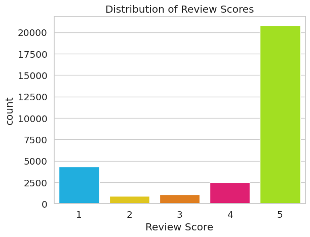

```python
sns.countplot(x='score', data=df, hue='score', palette=HAPPY_COLORS_PALETTE, dodge=False)
plt.title('Distribution of Review Scores')
plt.xlabel('Review Score')
plt.legend([],[], frameon=False)

plt.show()
```

Terlihat review untuk aplikasi Shopee di Singapore tampaknya didominasi oleh penilaian bintang lima (score: 5), menunjukkan bahwa mayoritas pengguna sangat puas dengan layanan yang diberikan.

### Wordcloud

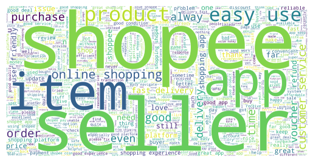

```python
wordcloud(df, 'content_clean')
```

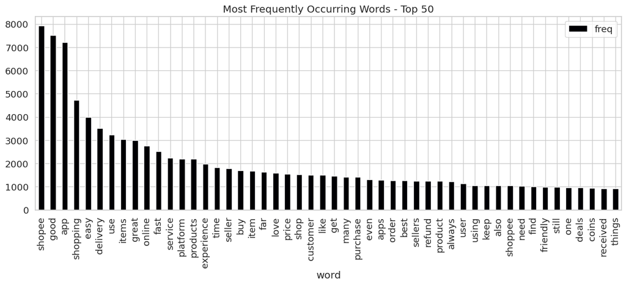

```python
graph_freq(df, 'content_clean')
```

### Frequency word based Score

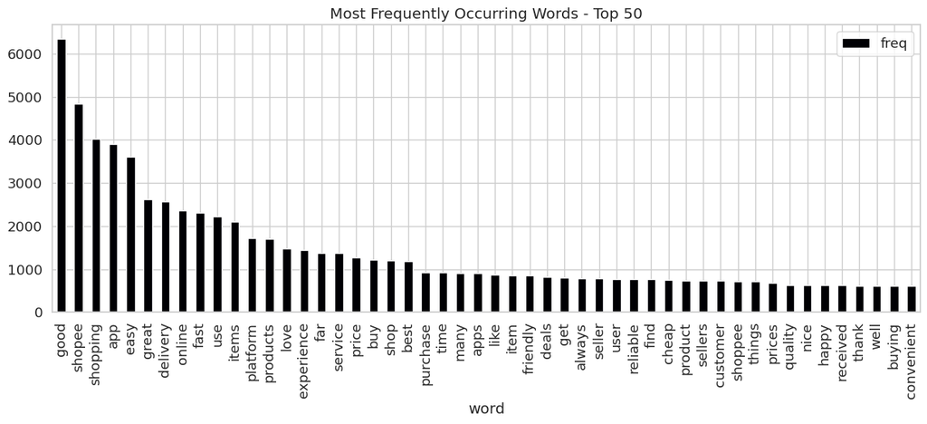

```python
graph_freq(df, 'content_clean', 'score', 4 and 5)
```

Melalui grafik di atas, kita bisa mengambil beberapa keyword seperti: **good, easy, great, fast** dan lainnya yang relevan untuk memberikan label **positive**.

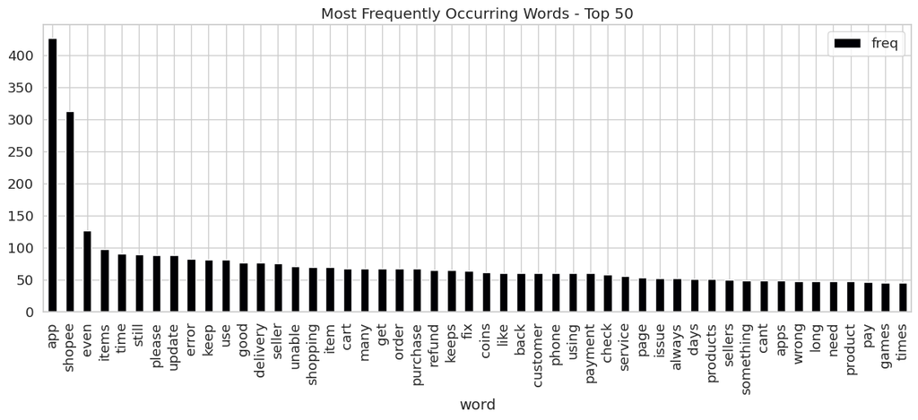

```python
graph_freq(df, 'content_clean', 'score', 1 and 2)
```

## Labelling

Memberikan label sesuai dengan yang sudah didefinisikan sebelumnya

```python
df['score_label'] = df['score'].apply(score_label)
df['label'] = df['content_clean'].apply(Label)
```

### Distribution Reviews

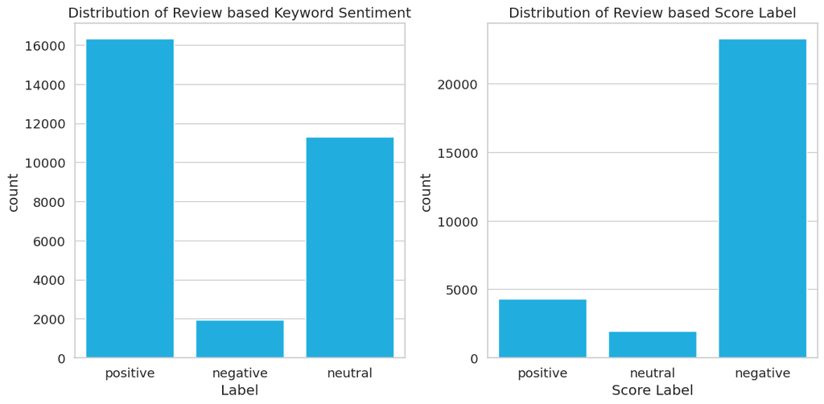

```python
fig, axs = plt.subplots(1, 2, figsize=(12, 6))

# Based Keyword Sentiment
sns.countplot(x='label', data=df, dodge=False, ax=axs[0])
axs[0].set_title('Distribution of Review based Keyword Sentiment')
axs[0].set_xlabel('Label')

# Based Score
sns.countplot(x='score_label', data=df, dodge=False, ax=axs[1])
axs[1].set_title('Distribution of Review based Score Label')
axs[1].set_xlabel('Score Label')

plt.tight_layout()
plt.show()
```

Terlihat dari grafik di atas terlalu jauh perbedaanya. Sebelumnya kita sudah melihat distribusi pada data score dan distribusi dengan score 5 lebih banyak.

Kemudian melakukan labeling dengan 2 cara yaitu berdasarkan keyword sentimen dan score.

Distribusi dengan keyword lebih masuk akal jika dibandingkan dengan score, karena pada distribusi dengan score 5 sebelumnya lebih banyak.

### Melihat frekuensi untuk **Positive Reviews**

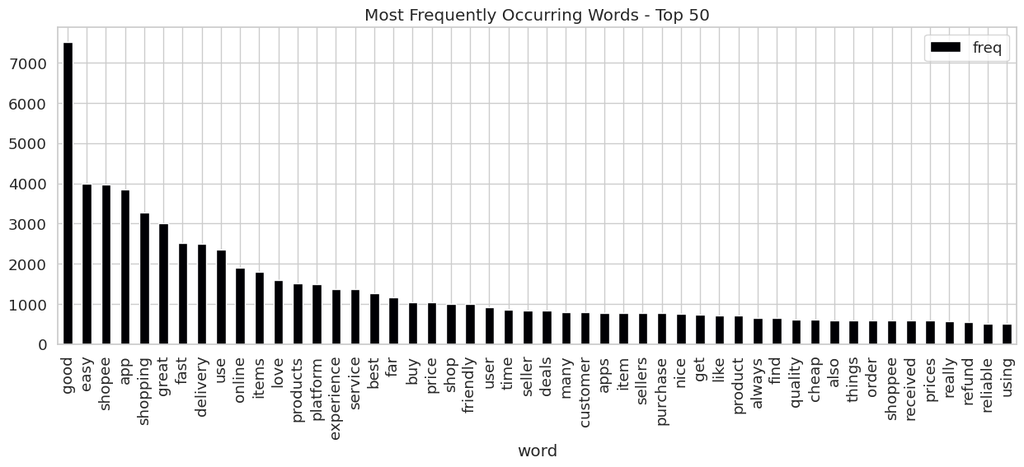

```python
graph_freq(df, 'content_clean', 'label', 'positive')
```

### Melihat frekuensi untuk **Neutral Reviews**

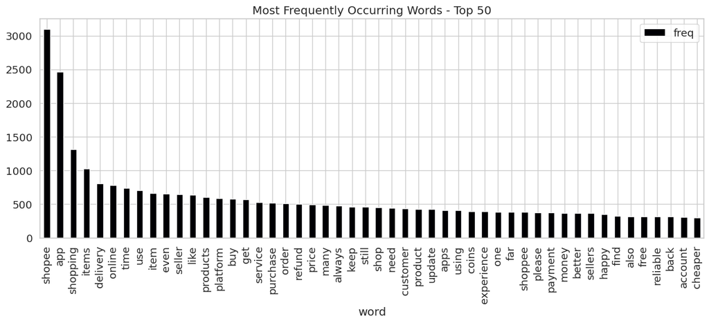

```python
graph_freq(df, 'content_clean', 'label', 'neutral')
```

### Melihat frekuensi untuk **Negative Reviews**

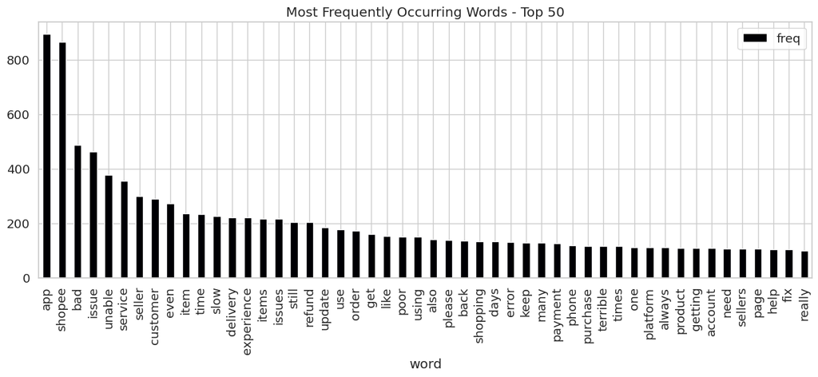

```python
graph_freq(df, 'content_clean', 'label', 'negative')
```

## Export dataset after Preprocessing

```python
df.to_csv(BaseDir + 'dataset/shopee-en-sg-all-preprocessed.csv', index=False)
```

## Modelling

```python
from sklearn.model_selection import train_test_split, GridSearchCV
from sklearn.svm import SVC
from sklearn.ensemble import RandomForestClassifier, GradientBoostingClassifier
from sklearn.feature_extraction.text import TfidfVectorizer
from sklearn.linear_model import LogisticRegression
from sklearn.metrics import accuracy_score
from sklearn.naive_bayes import BernoulliNB
from sklearn.pipeline import Pipeline
from sklearn.tree import DecisionTreeClassifier
from imblearn.under_sampling import RandomUnderSampler
from imblearn.over_sampling import SMOTE
from imblearn.pipeline import Pipeline as imPipeline
from sklearn.feature_extraction.text import CountVectorizer
from IPython.display import HTML
import joblib
```

```python
df = pd.read_csv(BaseDir + 'dataset/shopee-en-sg-all-preprocessed.csv')
```

```python
df.head(1)
```

|  | content | score | text_clean | text_tokenizingText | text_stopword | content_clean | stemmingText | score_label | label |
| --- | --- | --- | --- | --- | --- | --- | --- | --- | --- |
| 0 | I wouldn't use this app again, at least for a long time until they catch up on both the technological and human performances. The pages load extremely slowly or cannot load, they don't integrate with … | 1 | i wouldn t use this app again at least for a long time until they catch up on both the technological and human performances the pages load extremely slowly or cannot load they don t integrate with for… | ['i', 'wouldn', 't', 'use', 'this', 'app', 'again', 'at', 'least', 'for', 'a', 'long', 'time', 'until', 'they', 'catch', 'up', 'on', 'both', 'the', 'technological', 'and', 'human', 'performances', 'th… | ['use', 'app', 'least', 'long', 'time', 'catch', 'technological', 'human', 'performances', 'pages', 'load', 'extremely', 'slowly', 'load', 'integrate', 'foreign', 'credit', 'cards', 'errors', 'everywh… | use app least long time catch technological human performances pages load extremely slowly load integrate foreign credit cards errors everywhere shipping options stock availability welcome gift disapp… | use app least long time catch technolog human perform page load extrem slowli load integr foreign credit card error everywher ship option stock avail welcom gift disappear collect credenti still expec… | positive | positive |

```python
print(f'Terdapat {df.shape[0]} sample data')
```

```
Terdapat 29556 sample data
```

```python
df.dropna(inplace=True)
```

```python
df['label'].value_counts()
```

```
label
positive    16310
neutral     11314
negative     1931
Name: count, dtype: int64
```

### Encoding label:

- 'negative' : 0
- 'positive' : 1
- 'neutral' : 2

```python
df['label'] = df['label'].apply(map_labels)
df['score_label'] = df['score_label'].apply(map_labels)
```

### Percobaan 1 (ML wo GridSearch) - Data **Label**

- Data label dengan metode keyword sentiment
- Menggunakan Pipeline dengan beberapa model machine learning
- Menggunakan TFIDF
- Terdapat metode sampling dengan smote, random under sampling dan tanpa sampling
- Tanpa GridSearch

```python
X = df['content_clean']
y = df['label']

num_classes = len(y.unique())
print(f'Number of classes: {num_classes}')

X_train, X_test, y_train, y_test = train_test_split(X, y, test_size=0.2, random_state=42)

# Sampling
smote = SMOTE(random_state=42)
under_sampler = RandomUnderSampler(random_state=42)

models = {
    'Logistic Regression': LogisticRegression(max_iter=1000, C=1.0, solver='liblinear', multi_class='ovr', random_state=42),
    'Random Forest': RandomForestClassifier(n_estimators=100, max_depth=10, random_state=42),
    # 'Naive Bayes': BernoulliNB(alpha=1.0),
    'Decision Tree': DecisionTreeClassifier(max_depth=10, criterion='entropy', random_state=42),
    # 'Gradient Boosting': GradientBoostingClassifier(n_estimators=100, learning_rate=0.1, max_depth=3, random_state=42),
    'SVM': SVC(kernel='linear', C=1.0, decision_function_shape='ovr', random_state=42)
}

results = []

sampling_methods = {
    'None': None,
    'SMOTE': smote,
    'Random Under Sampling': under_sampler
}

for model_name, model in models.items():
    for sampling_name, sampler in sampling_methods.items():
        steps = [('tfidf', TfidfVectorizer(max_features=200, min_df=17, max_df=0.8))]

        if sampler:
            steps.append(('sampling', sampler))

        steps.append(('classifier', model))

        pipeline = imPipeline(steps)

        # Latih model
        pipeline.fit(X_train, y_train)

        # Simpan model
        model_filename = BaseDir + 'models/' + f"{model_name.replace(' ', '_')}_{sampling_name.replace(' ', '_')}.pkl"
        joblib.dump(pipeline, model_filename)
        print(f"Model saved to {model_filename}")

        # Prediksi
        y_pred_train = pipeline.predict(X_train)
        y_pred_test = pipeline.predict(X_test)

        # Evaluasi
        accuracy_train = accuracy_score(y_train, y_pred_train)
        accuracy_test = accuracy_score(y_test, y_pred_test)

        # Simpan hasil
        results.append({
            'Model': model_name,
            'Sampling Method': sampling_name,
            'Accuracy Train': accuracy_train,
            'Accuracy Test': accuracy_test
        })

results_df = pd.DataFrame(results)

def highlight_best_3(df):
    # 3 model terbaik berdasarkan 'Accuracy Test'
    top_3_indices = df.nlargest(3, 'Accuracy Test').index

    def highlight(row):
        return ['background-color: lightgreen' if i in top_3_indices else '' for i in row.index]

    return df.style.apply(highlight, axis=1)

# Tampilkan hasil dengan pewarnaan
styled_results_df = highlight_best_3(results_df)
display(styled_results_df)
```

```
Number of classes: 3
Model saved to /content/drive/MyDrive/Colab Notebooks/Sentiment-Analysis/models/Logistic_Regression_None.pkl
Model saved to /content/drive/MyDrive/Colab Notebooks/Sentiment-Analysis/models/Logistic_Regression_SMOTE.pkl
Model saved to /content/drive/MyDrive/Colab Notebooks/Sentiment-Analysis/models/Logistic_Regression_Random_Under_Sampling.pkl
Model saved to /content/drive/MyDrive/Colab Notebooks/Sentiment-Analysis/models/Random_Forest_None.pkl
Model saved to /content/drive/MyDrive/Colab Notebooks/Sentiment-Analysis/models/Random_Forest_SMOTE.pkl
Model saved to /content/drive/MyDrive/Colab Notebooks/Sentiment-Analysis/models/Random_Forest_Random_Under_Sampling.pkl
Model saved to /content/drive/MyDrive/Colab Notebooks/Sentiment-Analysis/models/Decision_Tree_None.pkl
Model saved to /content/drive/MyDrive/Colab Notebooks/Sentiment-Analysis/models/Decision_Tree_SMOTE.pkl
Model saved to /content/drive/MyDrive/Colab Notebooks/Sentiment-Analysis/models/Decision_Tree_Random_Under_Sampling.pkl
Model saved to /content/drive/MyDrive/Colab Notebooks/Sentiment-Analysis/models/SVM_None.pkl
Model saved to /content/drive/MyDrive/Colab Notebooks/Sentiment-Analysis/models/SVM_SMOTE.pkl
Model saved to /content/drive/MyDrive/Colab Notebooks/Sentiment-Analysis/models/SVM_Random_Under_Sampling.pkl
```

|  | Model | Sampling Method | Accuracy Train | Accuracy Test |
| --- | --- | --- | --- | --- |
| 0 | Logistic Regression | None | 0.972044 | 0.972593 |
| 1 | Logistic Regression | SMOTE | 0.958467 | 0.955676 |
| 2 | Logistic Regression | Random Under Sampling | 0.940661 | 0.938927 |
| 3 | Random Forest | None | 0.958975 | 0.955168 |
| 4 | Random Forest | SMOTE | 0.960751 | 0.955676 |
| 5 | Random Forest | Random Under Sampling | 0.951785 | 0.949586 |
| 6 | Decision Tree | None | 0.941338 | 0.942311 |
| 7 | Decision Tree | SMOTE | 0.908941 | 0.907799 |
| 8 | Decision Tree | Random Under Sampling | 0.906995 | 0.905261 |
| 9 | SVM | None | 0.974158 | 0.975300 |
| 10 | SVM | SMOTE | 0.972509 | 0.973778 |
| 11 | SVM | Random Under Sampling | 0.955676 | 0.956353 |

### Percobaan 2 (ML wo GridSearch) - Data Score Label

- Data label dengan metode score (rating reviews)
- Menggunakan Pipeline dengan beberapa model machine learning
- Menggunakan TFIDF
- Terdapat metode sampling dengan smote, random under sampling dan tanpa sampling
- Tanpa GridSearch

```python
X = df['content_clean']
y = df['score_label']

num_classes = len(y.unique())
print(f'Number of classes: {num_classes}')

X_train, X_test, y_train, y_test = train_test_split(X, y, test_size=0.2, random_state=42)

# Sampling
smote = SMOTE(random_state=42)
under_sampler = RandomUnderSampler(random_state=42)

models = {
    'Logistic Regression': LogisticRegression(max_iter=1000, C=1.0, solver='liblinear', multi_class='ovr', random_state=42),
    'Random Forest': RandomForestClassifier(n_estimators=100, max_depth=10, random_state=42),
    # 'Naive Bayes': BernoulliNB(alpha=1.0),
    'Decision Tree': DecisionTreeClassifier(max_depth=10, criterion='entropy', random_state=42),
    # 'Gradient Boosting': GradientBoostingClassifier(n_estimators=100, learning_rate=0.1, max_depth=3, random_state=42),
    'SVM': SVC(kernel='linear', C=1.0, decision_function_shape='ovr', random_state=42)
}

results = []

sampling_methods = {
    'None': None,
    'SMOTE': smote,
    'Random Under Sampling': under_sampler
}

for model_name, model in models.items():
    for sampling_name, sampler in sampling_methods.items():
        steps = [('tfidf', TfidfVectorizer(max_features=200, min_df=17, max_df=0.8))]

        if sampler:
            steps.append(('sampling', sampler))  # Terapkan teknik sampling jika ada

        steps.append(('classifier', model))

        pipeline = imPipeline(steps)

        # Latih model
        pipeline.fit(X_train, y_train)

        # Simpan model
        model_filename = f"{model_name.replace(' ', '_')}_{sampling_name.replace(' ', '_')}.pkl"
        joblib.dump(pipeline, model_filename)
        print(f"Model saved to {model_filename}")

        # Prediksi
        y_pred_train = pipeline.predict(X_train)
        y_pred_test = pipeline.predict(X_test)

        # Evaluasi
        accuracy_train = accuracy_score(y_train, y_pred_train)
        accuracy_test = accuracy_score(y_test, y_pred_test)

        # Simpan hasil ke list
        results.append({
            'Model': model_name,
            'Sampling Method': sampling_name,
            'Accuracy Train': accuracy_train,
            'Accuracy Test': accuracy_test
        })

results_df = pd.DataFrame(results)

def highlight_best_3(df):
    # 3 model terbaik berdasarkan 'Accuracy Test'
    top_3_indices = df.nlargest(3, 'Accuracy Test').index

    def highlight(row):
        return ['background-color: lightgreen' if i in top_3_indices else '' for i in row.index]

    return df.style.apply(highlight, axis=1)

styled_results_df = highlight_best_3(results_df)
display(styled_results_df)
```

[output not shown]

|  | Model | Sampling Method | Accuracy Train | Accuracy Test |
| --- | --- | --- | --- | --- |
| 0 | Logistic Regression | None | 0.861952 | 0.862460 |
| 1 | Logistic Regression | SMOTE | 0.780663 | 0.779902 |
| 2 | Logistic Regression | Random Under Sampling | 0.768609 | 0.768398 |
| 3 | Random Forest | None | 0.817205 | 0.817459 |
| 4 | Random Forest | SMOTE | 0.731010 | 0.709525 |
| 5 | Random Forest | Random Under Sampling | 0.711766 | 0.688547 |
| 6 | Decision Tree | None | 0.815725 | 0.812722 |
| 7 | Decision Tree | SMOTE | 0.605481 | 0.596853 |
| 8 | Decision Tree | Random Under Sampling | 0.629800 | 0.622230 |
| 9 | SVM | None | 0.860176 | 0.863982 |
| 10 | SVM | SMOTE | 0.771697 | 0.770597 |
| 11 | SVM | Random Under Sampling | 0.749366 | 0.744713 |

Menggunakan data Score Label, hasil akurasi masih belum mendapatkan akurasi >90%. Hal ini mungkin terjadi karena proses pelabelan dilakukan berdasarkan ratingnya. Jauh berbeda ketika pelabelan menggunakan metode keyword.

### Percobaan 3 (ML with GridSearch) - Data **Label**

- Data label dengan metode keyword sentiment
- Menggunakan Pipeline dengan beberapa model machine learning
- Menggunakan TFIDF
- Terdapat metode sampling dengan smote, random under sampling dan tanpa sampling
- Dengan GridSearch

```python
X = df['content_clean']
y = df['label']

num_classes = len(y.unique())
print(f'Number of classes: {num_classes}')

X_train, X_test, y_train, y_test = train_test_split(X, y, test_size=0.2, random_state=42)

# Sampling
smote = SMOTE(random_state=42)
under_sampler = RandomUnderSampler(random_state=42)

models = {
    'Logistic Regression': LogisticRegression(max_iter=1000, C=1.0, solver='liblinear', multi_class='ovr', random_state=42),
    'Random Forest': RandomForestClassifier(n_estimators=100, max_depth=10, random_state=42),
    # 'Naive Bayes': BernoulliNB(alpha=1.0),
    'Decision Tree': DecisionTreeClassifier(max_depth=10, criterion='entropy', random_state=42),
    # 'Gradient Boosting': GradientBoostingClassifier(n_estimators=100, learning_rate=0.1, max_depth=3, random_state=42),
    'SVM': SVC(kernel='linear', C=1.0, decision_function_shape='ovr', random_state=42)
}
results = []

# Parameter grid
param_grids = {
    'Logistic Regression': {
        'classifier__C': [0.1, 1.0, 10.0],
        'classifier__solver': ['liblinear', 'lbfgs']
    },
    'Random Forest': {
        'classifier__n_estimators': [50, 100, 200],
        'classifier__max_depth': [10, 20, None]
    },
    # 'Naive Bayes': {
    #     'classifier__alpha': [0.5, 1.0, 2.0]
    # },
    'Decision Tree': {
        'classifier__max_depth': [10, 20, None],
        'classifier__criterion': ['gini', 'entropy']
    },
    # 'Gradient Boosting': {
    #     'classifier__n_estimators': [50, 100, 200],
    #     'classifier__learning_rate': [0.01, 0.1, 1.0],
    #     'classifier__max_depth': [3, 5, 7]
    # },
    'SVM': {
        'classifier__C': [0.1, 1.0, 10.0],
        'classifier__kernel': ['linear', 'rbf']
    }
}

sampling_methods = {
    'None': None,
    'SMOTE': smote,
    'Random Under Sampling': under_sampler
}

for model_name, model in models.items():
    for sampling_name, sampler in sampling_methods.items():
        steps = [('tfidf', TfidfVectorizer(max_features=200, min_df=17, max_df=0.8))]

        if sampler:
            steps.append(('sampling', sampler))

        steps.append(('classifier', model))

        pipeline = imPipeline(steps)

        # Setup GridSearchCV
        param_grid = param_grids.get(model_name, {})
        grid_search = GridSearchCV(pipeline, param_grid, cv=5, scoring='accuracy', n_jobs=-1, verbose=1)

        # Latih model
        grid_search.fit(X_train, y_train)

        # Simpan model terbaik
        best_model_filename = BaseDir + 'models/' + f"{model_name.replace(' ', '_')}_{sampling_name.replace(' ', '_')}_best_model.pkl"
        joblib.dump(grid_search.best_estimator_, best_model_filename)
        print(f"Best model saved to {best_model_filename}")

        # Prediksi
        y_pred_train = grid_search.predict(X_train)
        y_pred_test = grid_search.predict(X_test)

        # Evaluasi
        accuracy_train = accuracy_score(y_train, y_pred_train)
        accuracy_test = accuracy_score(y_test, y_pred_test)

        # Simpan hasil
        results.append({
            'Model': model_name,
            'Sampling Method': sampling_name,
            'Best Params': grid_search.best_params_,
            'Accuracy Train': accuracy_train,
            'Accuracy Test': accuracy_test
        })

results_df = pd.DataFrame(results)

def highlight_best_3(df):
    # 3 model terbaik berdasarkan 'Accuracy Test'
    top_3_indices = df.nlargest(3, 'Accuracy Test').index

    def highlight(row):
        return ['background-color: lightgreen' if i in top_3_indices else '' for i in row.index]

    return df.style.apply(highlight, axis=1)

styled_results_df = highlight_best_3(results_df)
display(styled_results_df)
```

[output not shown]

|  | Model | Sampling Method | Best Params | Accuracy Train | Accuracy Test |
| --- | --- | --- | --- | --- | --- |
| 0 | Logistic Regression | None | {'classifier__C': 10.0, 'classifier__solver': 'liblinear'} | 0.975004 | 0.975808 |
| 1 | Logistic Regression | SMOTE | {'classifier__C': 10.0, 'classifier__solver': 'liblinear'} | 0.962993 | 0.960244 |
| 2 | Logistic Regression | Random Under Sampling | {'classifier__C': 10.0, 'classifier__solver': 'lbfgs'} | 0.952969 | 0.947386 |
| 3 | Random Forest | None | {'classifier__max_depth': 20, 'classifier__n_estimators': 200} | 0.976146 | 0.976485 |
| 4 | Random Forest | SMOTE | {'classifier__max_depth': None, 'classifier__n_estimators': 200} | 0.993825 | 0.972763 |
| 5 | Random Forest | Random Under Sampling | {'classifier__max_depth': 20, 'classifier__n_estimators': 200} | 0.961386 | 0.957875 |
| 6 | Decision Tree | None | {'classifier__criterion': 'entropy', 'classifier__max_depth': 20} | 0.977288 | 0.974962 |
| 7 | Decision Tree | SMOTE | {'classifier__criterion': 'entropy', 'classifier__max_depth': 20} | 0.976104 | 0.972424 |
| 8 | Decision Tree | Random Under Sampling | {'classifier__criterion': 'entropy', 'classifier__max_depth': 20} | 0.965234 | 0.961935 |
| 9 | SVM | None | {'classifier__C': 10.0, 'classifier__kernel': 'linear'} | 0.975512 | 0.976654 |
| 10 | SVM | SMOTE | {'classifier__C': 10.0, 'classifier__kernel': 'linear'} | 0.972297 | 0.973778 |
| 11 | SVM | Random Under Sampling | {'classifier__C': 1.0, 'classifier__kernel': 'linear'} | 0.955676 | 0.956353 |

## Import Library Deep Learning

```python
from sklearn.preprocessing import LabelEncoder
from sklearn.model_selection import train_test_split
from keras.preprocessing.text import Tokenizer
from keras.preprocessing.sequence import pad_sequences
from keras.utils import to_categorical
from keras.models import Sequential
from keras.layers import Embedding, LSTM, Dense
from keras.callbacks import EarlyStopping
from imblearn.under_sampling import RandomUnderSampler
from tensorflow.keras.models import Sequential
from tensorflow.keras.layers import Dense, Dropout, LSTM, Bidirectional, SimpleRNN, Embedding, SpatialDropout1D, GRU
from tensorflow.keras.preprocessing.sequence import pad_sequences
from tensorflow.keras.preprocessing.text import Tokenizer
from tensorflow.keras.utils import to_categorical
from tensorflow.keras.callbacks import EarlyStopping
from imblearn.over_sampling import SMOTE
from sklearn.metrics import accuracy_score
from tensorflow.keras.preprocessing.sequence import pad_sequences
from tensorflow.keras.preprocessing.text import Tokenizer
from tensorflow.keras.utils import to_categorical
from tensorflow.keras.callbacks import ModelCheckpoint, EarlyStopping, ReduceLROnPlateau
from imblearn.under_sampling import RandomUnderSampler
from sklearn.metrics import accuracy_score
import math
```

### Percobaan 4 (DL - LSTM)

```python
X = df['content_clean']
y = df['label']

num_classes = len(y.unique())
print(f'Number of classes: {num_classes}')

X_train, X_test, y_train, y_test = train_test_split(X, y, test_size=0.2, random_state=42)

# Tokenisasi teks
tokenizer = Tokenizer(num_words=5000, oov_token='<OOV>')
tokenizer.fit_on_texts(X_train)
word_index = tokenizer.word_index

# Konversi teks menjadi sequences
X_train_sequences = tokenizer.texts_to_sequences(X_train)
X_test_sequences = tokenizer.texts_to_sequences(X_test)

# Padding sequences
max_length = 100
X_train_padded = pad_sequences(X_train_sequences, maxlen=max_length, padding='post', truncating='post')
X_test_padded = pad_sequences(X_test_sequences, maxlen=max_length, padding='post', truncating='post')

# Konversi label menjadi categorical
y_train_categorical = to_categorical(y_train, num_classes=num_classes)
y_test_categorical = to_categorical(y_test, num_classes=num_classes)

# Create LSTM model
model = Sequential()
model.add(Embedding(input_dim=5000, output_dim=128, input_length=max_length))
model.add(LSTM(128))
model.add(Dropout(0.5))
model.add(Dense(num_classes, activation='softmax'))

model.compile(loss='categorical_crossentropy', optimizer='adam', metrics=['accuracy'])

# Callback
early_stop = EarlyStopping(monitor='val_loss', patience=3, restore_best_weights=True)

# Pelatihan model
history = model.fit(X_train_padded, y_train_categorical, epochs=10, batch_size=32, validation_data=(X_test_padded, y_test_categorical), callbacks=[early_stop])

# Evaluasi model
loss, accuracy = model.evaluate(X_test_padded, y_test_categorical, verbose=2)
print(f'Test Accuracy: {accuracy:.4f}')

# Menyimpan model
model.save(BaseDir + 'lstm_model.h5')
print("Model berhasil disimpan: 'lstm_model.h5'")
```

```
Number of classes: 3
185/185 - 12s - loss: 0.8672 - accuracy: 0.5552 - 12s/epoch - 67ms/step
Test Accuracy: 0.5552
Model berhasil disimpan: 'lstm_model.h5'
```

Percobaan dengan LSTM tidak mendapatkan akurasi yang diharapkan, hanya mendapatkan 55 %.

### Percobaan 5 (DL - BILSTM)

```python
X = df['content_clean']
y = df['label']

num_classes = len(y.unique())
print(f'Number of classes: {num_classes}')

X_train, X_test, y_train, y_test = train_test_split(X, y, test_size=0.2, random_state=42)

# Tokenisasi teks
tokenizer = Tokenizer(num_words=5000, oov_token='<OOV>')
tokenizer.fit_on_texts(X_train)
word_index = tokenizer.word_index

# Konversi teks menjadi sequences
X_train_sequences = tokenizer.texts_to_sequences(X_train)
X_test_sequences = tokenizer.texts_to_sequences(X_test)

# Padding sequences
max_length = 100
X_train_padded = pad_sequences(X_train_sequences, maxlen=max_length, padding='post', truncating='post')
X_test_padded = pad_sequences(X_test_sequences, maxlen=max_length, padding='post', truncating='post')

y_train_categorical = to_categorical(y_train, num_classes=num_classes)
y_test_categorical = to_categorical(y_test, num_classes=num_classes)

# Model BILSTM
model = Sequential()
model.add(Embedding(input_dim=5000, output_dim=128, input_length=max_length))
model.add(Bidirectional(LSTM(128)))
model.add(Dropout(0.5))
model.add(Dense(num_classes, activation='softmax'))

model.compile(loss='categorical_crossentropy', optimizer='adam', metrics=['accuracy'])

# Callback
early_stop = EarlyStopping(monitor='val_loss', patience=3, restore_best_weights=True)

# Pelatihan model
history = model.fit(X_train_padded, y_train_categorical, epochs=10, batch_size=32, validation_data=(X_test_padded, y_test_categorical), callbacks=[early_stop])

# Evaluasi model
loss, accuracy = model.evaluate(X_test_padded, y_test_categorical, verbose=2)
print(f'Test Accuracy: {accuracy:.4f}')

# Menyimpan model
model.save(BaseDIr + 'bilstm_model.keras')
print("Model berhasil disimpan: 'bilstm_model.keras'")
```

[output not shown]

### Percobaan 6 (DL - GRU)

```python
X = df['content_clean']
y = df['label']

num_classes = len(y.unique())
print(f'Number of classes: {num_classes}')

X_train, X_test, y_train, y_test = train_test_split(X, y, test_size=0.2, random_state=42)

# Tokenisasi teks
tokenizer = Tokenizer(num_words=5000, oov_token='<OOV>')
tokenizer.fit_on_texts(X_train)
word_index = tokenizer.word_index

# Konversi teks menjadi sequences
X_train_sequences = tokenizer.texts_to_sequences(X_train)
X_test_sequences = tokenizer.texts_to_sequences(X_test)

# Padding sequences
max_length = 100
X_train_padded = pad_sequences(X_train_sequences, maxlen=max_length, padding='post', truncating='post')
X_test_padded = pad_sequences(X_test_sequences, maxlen=max_length, padding='post', truncating='post')

# Konversi label menjadi categorical
y_train_categorical = to_categorical(y_train, num_classes=num_classes)
y_test_categorical = to_categorical(y_test, num_classes=num_classes)

# GRU model
model = Sequential()
model.add(Embedding(input_dim=5000, output_dim=128, input_length=max_length))
model.add(Bidirectional(GRU(128, dropout=0.2, return_sequences=True)))
model.add(Bidirectional(GRU(128)))
model.add(Dropout(0.5))
model.add(Dense(128, activation='relu'))
model.add(Dense(num_classes, activation='softmax'))

model.compile(loss='categorical_crossentropy', optimizer='adam', metrics=['accuracy'])

# Callback
early_stop = EarlyStopping(monitor='val_loss', patience=3, restore_best_weights=True)

# Pelatihan model
history = model.fit(X_train_padded, y_train_categorical, epochs=10, batch_size=32, validation_data=(X_test_padded, y_test_categorical), callbacks=[early_stop])

# Evaluasi model
loss, accuracy = model.evaluate(X_test_padded, y_test_categorical, verbose=2)
print(f'Test Accuracy: {accuracy:.4f}')

# Menyimpan model
model.save(BaseDir + 'gru_model.h5')
print("Model berhasil disimpan: 'gru_model.h5'")
```

```
Number of classes: 3
185/185 - 31s - loss: 0.0204 - accuracy: 0.9966 - 31s/epoch - 166ms/step
Test Accuracy: 0.9966
Model berhasil disimpan: 'gru_model.h5'
```

## Conclusion

Sehingga kedepannya model ini dapat digunakan untuk memprediksi sentiment.

*~ Thank you !*